# Training and testing final model M4 in LC-iCAP manuscript

### 5.0.1 Model error rates

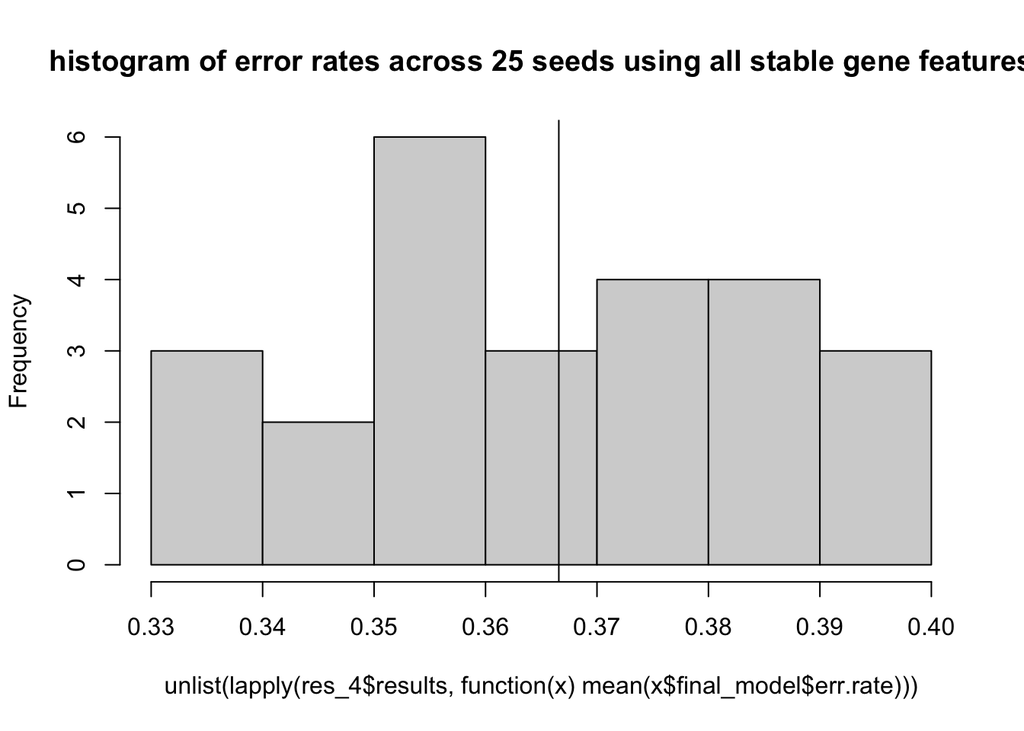

```r
hist(
  lapply(res_4$results, function(x) x$final_model$err.rate |> mean()) |> unlist(),
  main = "histogram of error rates across 25 seeds using all stable gene features"
)
abline(v=lapply(res_4$results, function(x) x$final_model$err.rate |> mean()) |> unlist() |> mean())
```

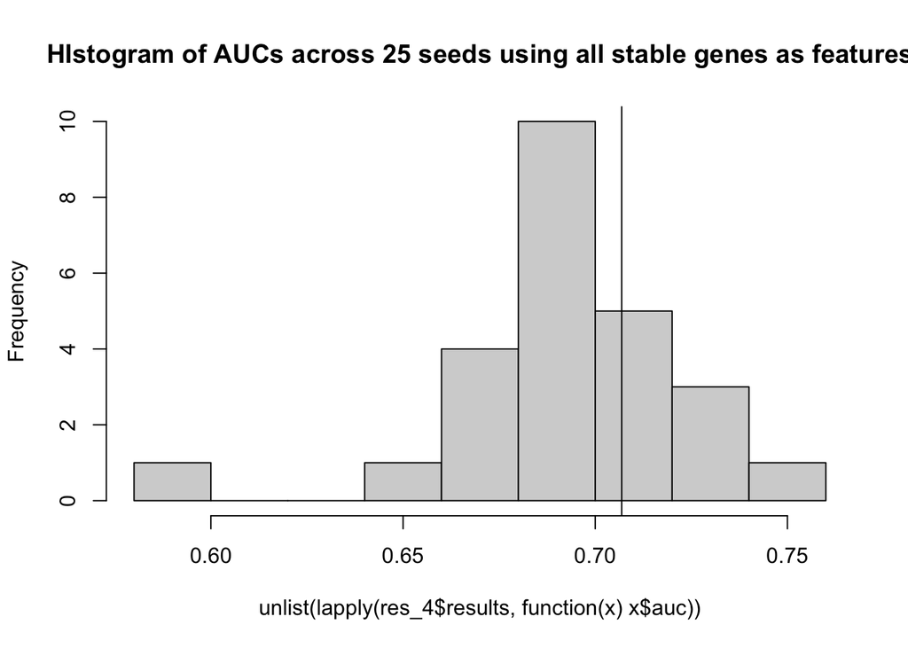

```r
hist(
  lapply(res_4$results, function(x) x$auc) |> unlist(),
  main = "HIstogram of AUCs across 25 seeds using all stable genes as features"
)
abline(v=res_4$results[[which.min(abs(aucs - q75))]]$auc)
```

### 5.0.2 Variable importance scores for selected model M4

M4 was selected for validation as the model with AUC at 75th percentile value

```r
varImp(model_4)
```

```
##                                    benign   malignant
## ADRB1                         -0.31028733 -0.31028733
## ADRB1.smoking_statuscurrent    2.01675574  2.01675574
## ALPK3                          2.87997723  2.87997723
## ALPK3.smoking_statuscurrent   -0.40032530 -0.40032530
## ANKRD37                        3.25727664  3.25727664
## BMP6                           1.38581213  1.38581213
## BMP6.smoking_statuscurrent     0.19903330  0.19903330
## CCDC66                         0.74662388  0.74662388
## CCDC66.smoking_statuscurrent   0.67230236  0.67230236
## CH25H                         -1.37725522 -1.37725522
## CH25H.smoking_statuscurrent    1.73568640  1.73568640
## CLIC4                         -1.53395581 -1.53395581
## CLIC4.smoking_statuscurrent   -1.03357029 -1.03357029
## CTF1                           2.97786017  2.97786017
## CTF1.smoking_statuscurrent    -0.01997775 -0.01997775
## CYP26B1                       -1.87200201 -1.87200201
## CYP26B1.smoking_statuscurrent  0.13123898  0.13123898
## DDIT4                          0.72157882  0.72157882
## DDIT4.smoking_statuscurrent   -0.64321804 -0.64321804
## DYSF                           0.77170658  0.77170658
## DYSF.smoking_statuscurrent     1.51708122  1.51708122
## FBXL5                          1.08690065  1.08690065
## FBXL5.smoking_statuscurrent    0.61937647  0.61937647
## FCF1                          -1.17654403 -1.17654403
## FCF1.smoking_statuscurrent    -0.66702146 -0.66702146
## GAS2L1                        -0.19133755 -0.19133755
## GAS2L1.smoking_statuscurrent   0.63944214  0.63944214
## HIF1A                          0.33102134  0.33102134
## HIF1A.smoking_statuscurrent    0.70158074  0.70158074
## IGFBP3                         1.56404697  1.56404697
## IGFBP3.smoking_statuscurrent  -0.64190082 -0.64190082
## IL1R2                          2.88146717  2.88146717
## IL1R2.smoking_statuscurrent   -0.37053931 -0.37053931
## KIFC2                         -0.43319305 -0.43319305
## KIFC2.smoking_statuscurrent   -0.47026463 -0.47026463
## KLF7                           0.68037195  0.68037195
## KLF7.smoking_statuscurrent     0.06614801  0.06614801
## MTND4                         -0.46903193 -0.46903193
## MTND4.smoking_statuscurrent    0.37564752  0.37564752
```

[output cut: 18 more lines]

```
## SDHA                          -0.12309935 -0.12309935
## SDHA.smoking_statuscurrent     1.02068798  1.02068798
## SESTD1                         0.04847253  0.04847253
## SESTD1.smoking_statuscurrent   1.31662246  1.31662246
## TCIRG1                        -0.40226166 -0.40226166
## TCIRG1.smoking_statuscurrent  -0.51429454 -0.51429454
## TRIM2                         -0.07385100 -0.07385100
## TRIM2.smoking_statuscurrent    0.14776277  0.14776277
## VPS13B                        -0.95691230 -0.95691230
## VPS13B.smoking_statuscurrent   0.82907006  0.82907006
## WNT4                          -0.89820561 -0.89820561
## WNT4.smoking_statuscurrent     0.04636747  0.04636747
## ANKRD37.smoking_statuscurrent -0.65107581 -0.65107581
## NDRG1.smoking_statuscurrent   -0.52154574 -0.52154574
## NOXA1.smoking_statuscurrent   -1.08450564 -1.08450564
```

## 5.1 Predictions

Model was selected for prediction against the blind test set

```r
make_predictions <- function(fp, ex, name, ver = 231016) {
  # Load wrapped results
  res <- readRDS(fp)
  if (is.null(res$results) || is.null(res$meta$chosen_index)) {
    stop("Expected new format: list(results=..., meta=list(chosen_index=..., chosen_seed=...)).")
  }

  runs <- res$results
  idx  <- res$meta$chosen_index
  if (idx < 1 || idx > length(runs)) stop("meta$chosen_index out of bounds.")
  model <- runs[[idx]]$final_model

  # External validation subset
  ex_ev <- ex[, ex$partition_new == "external_validation"]

  # Build EV design matrix to match training formula (~ . * smoking_status)
  ev <- data.frame(t(SummarizedExperiment::assay(ex_ev, "log2_normalized_counts")))
  ev$smoking_status <- SummarizedExperiment::colData(ex_ev)$smoking_status
  mm <- stats::model.matrix(~ . * smoking_status, ev)
  colnames(mm) <- gsub(":", ".", colnames(mm), fixed = TRUE)

  # Get predictor names
  xvars <- model$forest$xvar.names
  if (is.null(xvars) || !length(xvars)) {
    xvars <- rownames(randomForest::importance(model))
  }

  # If none match, try using gene symbols from rowData(ex_ev)
  if (sum(xvars %in% colnames(mm)) == 0 &&
      "gene_name" %in% colnames(SummarizedExperiment::rowData(ex_ev))) {
    m <- SummarizedExperiment::assay(ex_ev, "log2_normalized_counts")
    rn <- as.character(SummarizedExperiment::rowData(ex_ev)$gene_name)
    ok <- !is.na(rn) & nzchar(rn)
    m <- m[ok, , drop = FALSE]
    rownames(m) <- rn[ok]

    ev <- data.frame(t(m))
    ev$smoking_status <- ex_ev$smoking_status
    mm <- stats::model.matrix(~ . * smoking_status, ev)
    colnames(mm) <- gsub(":", ".", colnames(mm), fixed = TRUE)
  }

  # Align: add zero cols for missing, reorder to match model
  present <- intersect(colnames(mm), xvars)
  missing <- setdiff(xvars, present)
  if (length(missing)) {
    message("Adding zero columns for missing predictors: ",
            paste(head(missing, 10), collapse = ", "),
            if (length(missing) > 10) " ..." else "")
    add <- matrix(0, nrow(mm), length(missing), dimnames = list(NULL, missing))
    mm <- cbind(mm[, present, drop = FALSE], add)
  } else {
    mm <- mm[, present, drop = FALSE]
  }
  mm <- mm[, xvars, drop = FALSE]

  # Predict probabilities and label
  prob <- predict(model, as.data.frame(mm), type = "prob")
  preds <- tibble::as_tibble(prob, rownames = "precyte_uid") |>
    dplyr::select(-benign) |>
    dplyr::mutate(pred = dplyr::if_else(malignant > 0.5, "malignant", "benign")) |>
    dplyr::left_join(
      tibble::as_tibble(SummarizedExperiment::colData(ex_ev)) |>
        dplyr::select(precyte_uid, barcode),
      by = "precyte_uid"
    ) |>
    dplyr::relocate(barcode, .after = "precyte_uid")

  # Outputs
  out_dir <- "results/preds"
  if (!dir.exists(out_dir)) dir.create(out_dir, recursive = TRUE)
  readr::write_csv(preds, file.path(out_dir, sprintf("%s_%s_blind_validation_predictions2.csv", ver, name)))

  feat <- randomForest::importance(model) |>
    tibble::as_tibble(rownames = "feature") |>
    dplyr::arrange(dplyr::desc(MeanDecreaseGini))
  readr::write_csv(feat, file.path(out_dir, sprintf("%s_%s_rf_features2.csv", ver, name)))

  # Return a small summary invisibly
  invisible(list(
    preds = preds,
    features = feat,
    chosen_index = idx,
    chosen_seed = res$meta$chosen_seed
  ))
}
```

```r
make_predictions('results/res_4.rds', ex_pos, 'model_4')
```

## 5.2 Preds Histogram

histogram of 80 samples in the bind test set sorted by M4 prediction probabilities (note that these data contain a duplicate sample that was processed twice) In this analysis, the classes of the blind test set are blinded. Performance of M4 on the blind test set was done outside of this script using unblinded data.

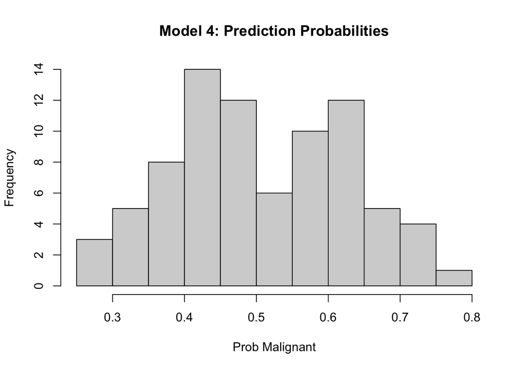

```r
hist(
  read_csv("results/preds/231016_model_4_blind_validation_predictions.csv")$malignant,
  main="Model 4: Prediction Probabilities",
  xlab="Prob Malignant"

)
```

### Training votes (prediction probabilities)

```r
assertthat::assert_that(all(ex[,rownames(model_4$votes)]$partition_new == "train"))
```

```
## [1] TRUE
```

```r
assertthat::assert_that(all(ex[,ex$partition_new == 'train']$precyte_uid %in% rownames(model_4$votes)))
```

```
## [1] TRUE
```

```r
preds_train = data.frame(malignant=model_4$votes[,2])

write.csv(file='results/preds_train/model_4.csv', preds_train, col.names = F, quote=F)
```

# 6 ROC curve showing Out of bag predictions of M4 on the training set of 96 samples

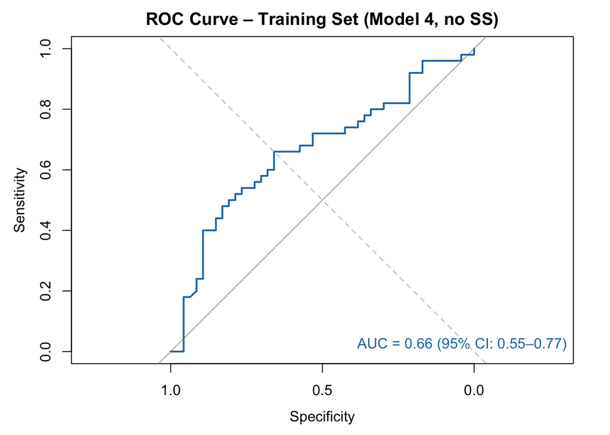

```r
# Merge predicted probabilities with true labels
true_labels <- colData(ex)[rownames(model_4$votes), "status"]
df_roc <- data.frame(
  actual = factor(true_labels, levels = c("benign", "malignant")),
  malignant = model_4$votes[, "malignant"]
)

# Compute ROC and AUC
roc_obj <- roc(df_roc$actual, df_roc$malignant, levels = c("benign", "malignant"), direction = "<")
auc_val <- auc(roc_obj)
auc_ci <- ci.auc(roc_obj)

# draw to the HTML output
plot(roc_obj, col = "#1f78b4", lwd = 2, main = "ROC Curve – Training Set (Model 4, no SS)")
legend("bottomright",
       legend = sprintf("AUC = %.2f (95%% CI: %.2f–%.2f)", auc_val, auc_ci[1], auc_ci[3]),
       bty = "n", text.col = "#1f78b4")
abline(a = 0, b = 1, lty = 2, col = "gray")
```

```r
# copy the current plot to a PDF
grDevices::dev.copy2pdf(file = "results/preds_train/ROC_Model4_Train.pdf", width = 6, height = 6)
```

```r
grDevices::dev.off()
```